# MATH 237 Project 1 - Amazon Sales Predictions

### Email: rivera.tania275@csu.fullerton.edu

### CWID: 884546623

## Context:

Amazon is one of the biggest hubs of online shopping of the modern day, and has not only shaped how people shop, but also how they sell. Boasting over 9.7 million registered vendors worldwide, many use amazon.com to make a living. Using Predictive Modeling, vendors can now use available data (such as the data provided in this Amazon Sales Dataset) to predict how many sales their product is estimated to get based on its features.

## What This Notebook Looks To Answer:

What features of a product will influence higher ratings or reviews for a product? Does the rating or price of a product determine how many sales (assuming rating_count is only made up of customers who bought the product) a product will receive?

## Limitations Of This Dataset:

The data in the Amazon Sales Dataset (linked below) was scraped from the official Amazon website. This Dataset does not include any actual sales data, which limit how accurately the predictive model can predict sales based on the features provided. All analysis and conclusions are made assuming all reviews were made by customers who bought the products listed. All price categories are also provided in Indian Rupee, which may affect the conclusion. Despite this, all efforts were made to convert data types and prices into something workable.

### Link to Dataset: https://www.kaggle.com/datasets/karkavelrajaj/amazon-sales-dataset/data

## Outline:

### Part 1 - Data Wrangling

- Remove redundant features
- Handle missing data
- Convert data types from object to float
- Convert currency of price categories to USD

### Part 2 - Exploratory Data Analysis

- Visualize dataset features vs. rating and rating_count
- Visualize `main_category` vs. `rating` and `rating_count`
- Visualize the distribution of `rating` and `rating_count`
- Visualize the distribution of `discount_percentage`
- Visualize the distribution of `discount_percentage`
- Visualize relationships between features

### Part 3 - Model Selection and Evaluation

- One-hot encode the `main_category` feature.
- Apply Transformation to target
- Train and Evaluate Our Models

### Part 4 - Predictive Modeling

- Make Predictions

### Part 5 - Conclusion

## Import Libraries

```python
# Import libraries
import pandas as pd
import numpy as np
import matplotlib.pyplot as plt
import seaborn as sns

import pandas as pd
import numpy as np
import matplotlib.pyplot as plt
import seaborn as sns
from sklearn.linear_model import LinearRegression
from sklearn.model_selection import train_test_split, cross_val_score
from sklearn.metrics import r2_score, mean_squared_error
from sklearn.preprocessing import StandardScaler

# Set random seed
np.random.seed(42)
```

## Set Up Plotting

```python
# Set up plotting
plt.style.use('default')
plt.rcParams['figure.figsize'] = (10, 6)
plt.rcParams['figure.dpi'] = 100
```

## Load the Dataset

```python
# Connect to Google Drive
from google.colab import drive
drive.mount('/content/drive')

# Load the Amazon dataset
data = pd.read_csv('/content/drive/My Drive/MATH237/amazon.csv')
print(f"Dataset shape: {data.shape}")
data.head()
```

```
Dataset shape: (1465, 16)
```

|  | product_id | product_name | category | discounted_price | actual_price | discount_percentage | rating | rating_count | about_product | user_id | user_name | review_id | review_title | review_content | img_link | product_link |
| --- | --- | --- | --- | --- | --- | --- | --- | --- | --- | --- | --- | --- | --- | --- | --- | --- |
| 0 | B07JW9H4J1 | Wayona Nylon Braided USB to Lightning Fast Cha... | Computers&Accessories\|Accessories&Peripherals\|... | ₹399 | ₹1,099 | 64% | 4.2 | 24,269 | High Compatibility : Compatible With iPhone 12... | AG3D6O4STAQKAY2UVGEUV46KN35Q,AHMY5CWJMMK5BJRBB... | Manav,Adarsh gupta,Sundeep,S.Sayeed Ahmed,jasp... | R3HXWT0LRP0NMF,R2AJM3LFTLZHFO,R6AQJGUP6P86,R1K... | Satisfied,Charging is really fast,Value for mo... | Looks durable Charging is fine tooNo complains... | https://m.media-amazon.com/images/W/WEBP_40237... | https://www.amazon.in/Wayona-Braided-WN3LG1-Sy... |
| 1 | B098NS6PVG | Ambrane Unbreakable 60W / 3A Fast Charging 1.5... | Computers&Accessories\|Accessories&Peripherals\|... | ₹199 | ₹349 | 43% | 4.0 | 43,994 | Compatible with all Type C enabled devices, be... | AECPFYFQVRUWC3KGNLJIOREFP5LQ,AGYYVPDD7YG7FYNBX... | ArdKn,Nirbhay kumar,Sagar Viswanathan,Asp,Plac... | RGIQEG07R9HS2,R1SMWZQ86XIN8U,R2J3Y1WL29GWDE,RY... | A Good Braided Cable for Your Type C Device,Go... | I ordered this cable to connect my phone to An... | https://m.media-amazon.com/images/W/WEBP_40237... | https://www.amazon.in/Ambrane-Unbreakable-Char... |
| 2 | B096MSW6CT | Sounce Fast Phone Charging Cable & Data Sync U... | Computers&Accessories\|Accessories&Peripherals\|... | ₹199 | ₹1,899 | 90% | 3.9 | 7,928 | 【 Fast Charger& Data Sync】-With built-in safet... | AGU3BBQ2V2DDAMOAKGFAWDDQ6QHA,AESFLDV2PT363T2AQ... | Kunal,Himanshu,viswanath,sai niharka,saqib mal... | R3J3EQQ9TZI5ZJ,R3E7WBGK7ID0KV,RWU79XKQ6I1QF,R2... | Good speed for earlier versions,Good Product,W... | Not quite durable and sturdy,https://m.media-a... | https://m.media-amazon.com/images/W/WEBP_40237... | https://www.amazon.in/Sounce-iPhone-Charging-C... |
| 3 | B08HDJ86NZ | boAt Deuce USB 300 2 in 1 Type-C & Micro USB S... | Computers&Accessories\|Accessories&Peripherals\|... | ₹329 | ₹699 | 53% | 4.2 | 94,363 | The boAt Deuce USB 300 2 in 1 cable is compati... | AEWAZDZZJLQUYVOVGBEUKSLXHQ5A,AG5HTSFRRE6NL3M5S... | Omkar dhale,JD,HEMALATHA,Ajwadh a.,amar singh ... | R3EEUZKKK9J36I,R3HJVYCLYOY554,REDECAZ7AMPQC,R1... | Good product,Good one,Nice,Really nice product... | Good product,long wire,Charges good,Nice,I bou... | https://m.media-amazon.com/images/I/41V5FtEWPk... | https://www.amazon.in/Deuce-300-Resistant-Tang... |
| 4 | B08CF3B7N1 | Portronics Konnect L 1.2M Fast Charging 3A 8 P... | Computers&Accessories\|Accessories&Peripherals\|... | ₹154 | ₹399 | 61% | 4.2 | 16,905 | [CHARGE & SYNC FUNCTION]- This cable comes wit... | AE3Q6KSUK5P75D5HFYHCRAOLODSA,AFUGIFH5ZAFXRDSZH... | rahuls6099,Swasat Borah,Ajay Wadke,Pranali,RVK... | R1BP4L2HH9TFUP,R16PVJEXKV6QZS,R2UPDB81N66T4P,R... | As good as original,Decent,Good one for second... | Bought this instead of original apple, does th... | https://m.media-amazon.com/images/W/WEBP_40237... | https://www.amazon.in/Portronics-Konnect-POR-1... |

## Exploring The Dataset

```python
# Basic DataFrame information
print(f"Dataset shape: {data.shape} (rows, columns)")
print(f"The dataset consists of: {data.shape[0]} products, {data.shape[1]} features")
print(f"Column names: {list(data.columns)}")
```

```
Dataset shape: (1465, 16) (rows, columns)
The dataset consists of: 1465 products, 16 features
Column names: ['product_id', 'product_name', 'category', 'discounted_price', 'actual_price', 'discount_percentage', 'rating', 'rating_count', 'about_product', 'user_id', 'user_name', 'review_id', 'review_title', 'review_content', 'img_link', 'product_link']
```

All the columns and their data types:

```python
print("Column information:")
print(data.info())
```

```
Column information:
<class 'pandas.core.frame.DataFrame'>
RangeIndex: 1465 entries, 0 to 1464
Data columns (total 16 columns):
 #   Column               Non-Null Count  Dtype
---  ------               --------------  -----
 0   product_id           1465 non-null   object
 1   product_name         1465 non-null   object
 2   category             1465 non-null   object
 3   discounted_price     1465 non-null   object
 4   actual_price         1465 non-null   object
 5   discount_percentage  1465 non-null   object
 6   rating               1465 non-null   object
 7   rating_count         1463 non-null   object
 8   about_product        1465 non-null   object
 9   user_id              1465 non-null   object
 10  user_name            1465 non-null   object
 11  review_id            1465 non-null   object
 12  review_title         1465 non-null   object
 13  review_content       1465 non-null   object
 14  img_link             1465 non-null   object
 15  product_link         1465 non-null   object
dtypes: object(16)
memory usage: 183.3+ KB
None
```

## Locate Missing Values

```python
# Check for missing data
print("Missing values by column:")
missing_counts = data.isnull().sum()
print(missing_counts)
```

```
Missing values by column:
product_id             0
product_name           0
category               0
discounted_price       0
actual_price           0
discount_percentage    0
rating                 0
rating_count           2
about_product          0
user_id                0
user_name              0
review_id              0
review_title           0
review_content         0
img_link               0
product_link           0
dtype: int64
```

Only these rows are missing:

```python
print("\nRows with missing data:")
print(data[data.isnull().any(axis=1)])
```

```
Rows with missing data:
     product_id                                       product_name  \
282  B0B94JPY2N  Amazon Brand - Solimo 65W Fast Charging Braide...
324  B0BQRJ3C47  REDTECH USB-C to Lightning Cable 3.3FT, [Apple...

                                              category discounted_price  \
282  Computers&Accessories|Accessories&Peripherals|...             ₹199
324  Computers&Accessories|Accessories&Peripherals|...             ₹249

    actual_price discount_percentage rating rating_count  \
282         ₹999                 80%    3.0          NaN
324         ₹999                 75%    5.0          NaN

                                         about_product  \
282  USB C to C Cable: This cable has type C connec...
324  💎[The Fastest Charge] - This iPhone USB C cabl...

                          user_id    user_name      review_id  \
282  AE7CFHY23VAJT2FI4NZKKP6GS2UQ       Pranav   RUB7U91HVZ30
324  AGJC5O5H5BBXWUV7WRIEIOOR3TVQ  Abdul Gafur  RQXD5SAMMPC6L

                                     review_title  \
282  The cable works but is not 65W as advertised
324                               Awesome Product

                                        review_content  \
282  I have a pd supported car charger and I bought...
324  Quick delivery.Awesome ProductPacking was good...

                                              img_link  \
282  https://m.media-amazon.com/images/W/WEBP_40237...
324  https://m.media-amazon.com/images/I/31-q0xhaTA...

                                          product_link
282  https://www.amazon.in/Amazon-Brand-Charging-Su...
324  https://www.amazon.in/REDTECH-Lightning-Certif...
```

The dataset is mostly complete.

```python
complete_cases = len(data.dropna())
print(f"Total missing values: {missing_counts.sum()}")
print(f"Complete cases: {complete_cases} out of {len(data)}")
```

```
Total missing values: 2
Complete cases: 1463 out of 1465
```

## Observations

### The Dataset Itself:

The Amazon Sales Dataset has 16 features and 1,465 entries. Of the features listed, these are of interest: `product_name`, `category`, `discounted_price`, `actual_price`, `discount_percentage`, `rating`, and `rating_count`.

### Missing Data:

The dataset is mostly complete with only 2 entries missing for `rating_count`.

### Data Types:

All features of interest are of the object data type, which will not work well for visualisation and predictive modeling. The data will need to be converted into numeric types so that we can begin working with it.

### Additional Notes:

Some entries in the dataset are repeated.

# Part 1 - Data Wrangling

Get rid of any columns we do not need.

```python
# Create a copy to begin cleaning the data
data_clean = data.copy()

# Drop all redundant columns for our purposes
data_clean.drop(columns=['about_product', 'user_id', 'user_name', 'review_id', 'review_title', 'review_content', 'img_link', 'product_link'], inplace=True)
print(data_clean.info())
```

```
<class 'pandas.core.frame.DataFrame'>
RangeIndex: 1465 entries, 0 to 1464
Data columns (total 8 columns):
 #   Column               Non-Null Count  Dtype
---  ------               --------------  -----
 0   product_id           1465 non-null   object
 1   product_name         1465 non-null   object
 2   category             1465 non-null   object
 3   discounted_price     1465 non-null   object
 4   actual_price         1465 non-null   object
 5   discount_percentage  1465 non-null   object
 6   rating               1465 non-null   object
 7   rating_count         1463 non-null   object
dtypes: object(8)
memory usage: 91.7+ KB
None
```

## Create The `main_category` Feature

This is done so that the categories are a bit easier to look through.

```python
# Create a new column
data_clean['main_category'] = data_clean['category'].apply(lambda x: x.split('|')[0])

# Print values in main_category
print("Categories after simplification:")
print(data_clean['main_category'].value_counts())
display(data_clean.head())
```

```
Categories after simplification:
main_category
Electronics              526
Computers&Accessories    453
Home&Kitchen             448
OfficeProducts            31
MusicalInstruments         2
HomeImprovement            2
Toys&Games                 1
Car&Motorbike              1
Health&PersonalCare        1
Name: count, dtype: int64
```

|  | product_id | product_name | category | discounted_price | actual_price | discount_percentage | rating | rating_count | main_category |
| --- | --- | --- | --- | --- | --- | --- | --- | --- | --- |
| 0 | B07JW9H4J1 | Wayona Nylon Braided USB to Lightning Fast Cha... | Computers&Accessories\|Accessories&Peripherals\|... | ₹399 | ₹1,099 | 64% | 4.2 | 24,269 | Computers&Accessories |
| 1 | B098NS6PVG | Ambrane Unbreakable 60W / 3A Fast Charging 1.5... | Computers&Accessories\|Accessories&Peripherals\|... | ₹199 | ₹349 | 43% | 4.0 | 43,994 | Computers&Accessories |
| 2 | B096MSW6CT | Sounce Fast Phone Charging Cable & Data Sync U... | Computers&Accessories\|Accessories&Peripherals\|... | ₹199 | ₹1,899 | 90% | 3.9 | 7,928 | Computers&Accessories |
| 3 | B08HDJ86NZ | boAt Deuce USB 300 2 in 1 Type-C & Micro USB S... | Computers&Accessories\|Accessories&Peripherals\|... | ₹329 | ₹699 | 53% | 4.2 | 94,363 | Computers&Accessories |
| 4 | B08CF3B7N1 | Portronics Konnect L 1.2M Fast Charging 3A 8 P... | Computers&Accessories\|Accessories&Peripherals\|... | ₹154 | ₹399 | 61% | 4.2 | 16,905 | Computers&Accessories |

## Handle Missing Data Using Listwise Deletion

Use Listwise deletion to get rid of the only two entries with missing data. Since the amount of missing data is small compared to the rest of the dataset, this can be done.

```python
data_clean = data_clean.dropna()

print("Listwise Deletion Results:")
print("=" * 35)
print(f"Original dataset: {len(data)} entries")
print(f"After listwise deletion: {len(data_clean)} entries")
print(f"Lost: {len(data) - len(data_clean)} entries ({(len(data) - len(data_clean))/len(data)*100:.1f}%)")

# Apply main_category to the original dataset
data['main_category'] = data['category'].apply(lambda x: x.split('|')[0])

# Check if our sample is still representative
print(f"\nCategory distribution comparison:")
print(f"Original:")
original_categories = data['main_category'].value_counts(normalize=True).round(3)
print(original_categories)

print(f"\nAfter deletion:")
complete_categories = data_clean['main_category'].value_counts(normalize=True).round(3)
print(complete_categories)
```

```
Listwise Deletion Results:
===================================
Original dataset: 1465 entries
After listwise deletion: 1463 entries
Lost: 2 entries (0.1%)

Category distribution comparison:
Original:
main_category
Electronics              0.359
Computers&Accessories    0.309
Home&Kitchen             0.306
OfficeProducts           0.021
MusicalInstruments       0.001
HomeImprovement          0.001
Toys&Games               0.001
Car&Motorbike            0.001
Health&PersonalCare      0.001
Name: proportion, dtype: float64

After deletion:
main_category
Electronics              0.360
Computers&Accessories    0.308
Home&Kitchen             0.306
OfficeProducts           0.021
MusicalInstruments       0.001
HomeImprovement          0.001
Toys&Games               0.001
Car&Motorbike            0.001
Health&PersonalCare      0.001
Name: proportion, dtype: float64
```

Listwise deletion was a success! The category distribution stayed mostly the same.

## Convert Data Type to Float And Prices To USD

The original dataset provides our data as objects, so we need to convert our data to float. In addition, the price categories are provided in Indian Rupee, so it needs to be converted into USD.

```python
# Function to clean and convert currency columns
def clean_currency(price_str):
    if isinstance(price_str, str):
        return float(price_str.replace('₹', '').replace(',', ''))
    return float(price_str)

# Apply the cleaning function to price columns
data_clean['discounted_price'] = data_clean['discounted_price'].apply(clean_currency)
data_clean['actual_price'] = data_clean['actual_price'].apply(clean_currency)

# Convert discount_percentage to float
data_clean['discount_percentage'] = data_clean['discount_percentage'].str.replace('%', '').astype(float)

# Convert rating and rating_count to float, handling potential errors
data_clean['rating'] = pd.to_numeric(data_clean['rating'], errors='coerce')
data_clean['rating_count'] = data_clean['rating_count'].str.replace(',', '').astype(float)

# Drop rows with missing rating values
data_clean.dropna(subset=['rating'], inplace=True)


print("Data types after conversion:")
print(data_clean.info())
print("\nSample of cleaned data:")
display(data_clean.head())
```

```
Data types after conversion:
<class 'pandas.core.frame.DataFrame'>
Index: 1462 entries, 0 to 1464
Data columns (total 9 columns):
 #   Column               Non-Null Count  Dtype
---  ------               --------------  -----
 0   product_id           1462 non-null   object
 1   product_name         1462 non-null   object
 2   category             1462 non-null   object
 3   discounted_price     1462 non-null   float64
 4   actual_price         1462 non-null   float64
 5   discount_percentage  1462 non-null   float64
 6   rating               1462 non-null   float64
 7   rating_count         1462 non-null   float64
 8   main_category        1462 non-null   object
dtypes: float64(5), object(4)
memory usage: 114.2+ KB
None

Sample of cleaned data:
```

|  | product_id | product_name | category | discounted_price | actual_price | discount_percentage | rating | rating_count | main_category |
| --- | --- | --- | --- | --- | --- | --- | --- | --- | --- |
| 0 | B07JW9H4J1 | Wayona Nylon Braided USB to Lightning Fast Cha... | Computers&Accessories\|Accessories&Peripherals\|... | 399.0 | 1099.0 | 64.0 | 4.2 | 24269.0 | Computers&Accessories |
| 1 | B098NS6PVG | Ambrane Unbreakable 60W / 3A Fast Charging 1.5... | Computers&Accessories\|Accessories&Peripherals\|... | 199.0 | 349.0 | 43.0 | 4.0 | 43994.0 | Computers&Accessories |
| 2 | B096MSW6CT | Sounce Fast Phone Charging Cable & Data Sync U... | Computers&Accessories\|Accessories&Peripherals\|... | 199.0 | 1899.0 | 90.0 | 3.9 | 7928.0 | Computers&Accessories |
| 3 | B08HDJ86NZ | boAt Deuce USB 300 2 in 1 Type-C & Micro USB S... | Computers&Accessories\|Accessories&Peripherals\|... | 329.0 | 699.0 | 53.0 | 4.2 | 94363.0 | Computers&Accessories |
| 4 | B08CF3B7N1 | Portronics Konnect L 1.2M Fast Charging 3A 8 P... | Computers&Accessories\|Accessories&Peripherals\|... | 154.0 | 399.0 | 61.0 | 4.2 | 16905.0 | Computers&Accessories |

Now we convert the currency in the price categories to USD.

```python
# Approximate exchange rate (as of late 2023/early 2024)
INR_TO_USD_RATE = 0.012

# Convert price columns to USD
data_clean['discounted_price_usd'] = data_clean['discounted_price'] * INR_TO_USD_RATE
data_clean['actual_price_usd'] = data_clean['actual_price'] * INR_TO_USD_RATE

print("Prices converted to USD:")
display(data_clean[['discounted_price', 'discounted_price_usd', 'actual_price', 'actual_price_usd']].head())
```

```
Prices converted to USD:
```

|  | discounted_price | discounted_price_usd | actual_price | actual_price_usd |
| --- | --- | --- | --- | --- |
| 0 | 399.0 | 4.788 | 1099.0 | 13.188 |
| 1 | 199.0 | 2.388 | 349.0 | 4.188 |
| 2 | 199.0 | 2.388 | 1899.0 | 22.788 |
| 3 | 329.0 | 3.948 | 699.0 | 8.388 |
| 4 | 154.0 | 1.848 | 399.0 | 4.788 |

## Remove Repeated Entries

```python
# Check for duplicate rows
print(f"Number of duplicate rows before dropping: {data_clean.duplicated().sum()}")

# Remove duplicate rows
data_clean.drop_duplicates(inplace=True)

print(f"Number of duplicate rows after dropping: {data_clean.duplicated().sum()}")
print(f"Shape of data_clean after dropping duplicates: {data_clean.shape}")
```

```
Number of duplicate rows before dropping: 81
Number of duplicate rows after dropping: 0
Shape of data_clean after dropping duplicates: (1381, 11)
```

Now that our dataset has been cleaned, we are ready to explore and analyze our data.

# Part 2 - Exploratory Data Analysis

## Visualize dataset features vs. `rating` and `rating_count`

Visualize the relationship between the target features (`rating` and `rating_count`) and the rest of the dataset's features using scatter plots.

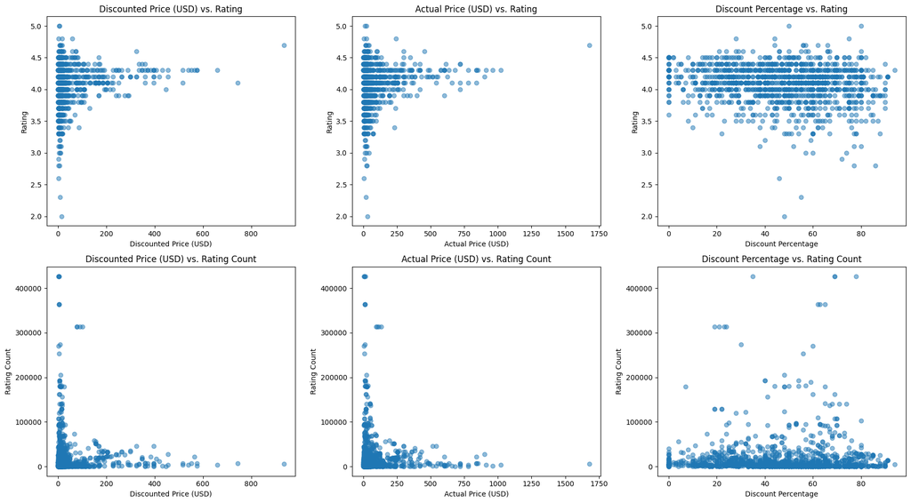

```python
# Create scatter plots
fig, axes = plt.subplots(nrows=2, ncols=3, figsize=(18, 10))

# Plot 1: Discounted Price vs. Rating
axes[0, 0].scatter(data_clean['discounted_price_usd'], data_clean['rating'], alpha=0.5)
axes[0, 0].set_title('Discounted Price (USD) vs. Rating')
axes[0, 0].set_xlabel('Discounted Price (USD)')
axes[0, 0].set_ylabel('Rating')

# Plot 2: Actual Price vs. Rating
axes[0, 1].scatter(data_clean['actual_price_usd'], data_clean['rating'], alpha=0.5)
axes[0, 1].set_title('Actual Price (USD) vs. Rating')
axes[0, 1].set_xlabel('Actual Price (USD)')
axes[0, 1].set_ylabel('Rating')

# Plot 3: Discount Percentage vs. Rating
axes[0, 2].scatter(data_clean['discount_percentage'], data_clean['rating'], alpha=0.5)
axes[0, 2].set_title('Discount Percentage vs. Rating')
axes[0, 2].set_xlabel('Discount Percentage')
axes[0, 2].set_ylabel('Rating')

# Plot 4: Discounted Price vs. Rating Count
axes[1, 0].scatter(data_clean['discounted_price_usd'], data_clean['rating_count'], alpha=0.5)
axes[1, 0].set_title('Discounted Price (USD) vs. Rating Count')
axes[1, 0].set_xlabel('Discounted Price (USD)')
axes[1, 0].set_ylabel('Rating Count')

# Plot 5: Actual Price vs. Rating Count
axes[1, 1].scatter(data_clean['actual_price_usd'], data_clean['rating_count'], alpha=0.5)
axes[1, 1].set_title('Actual Price (USD) vs. Rating Count')
axes[1, 1].set_xlabel('Actual Price (USD)')
axes[1, 1].set_ylabel('Rating Count')

# Plot 6: Discount Percentage vs. Rating Count
axes[1, 2].scatter(data_clean['discount_percentage'], data_clean['rating_count'], alpha=0.5)
axes[1, 2].set_title('Discount Percentage vs. Rating Count')
axes[1, 2].set_xlabel('Discount Percentage')
axes[1, 2].set_ylabel('Rating Count')

plt.tight_layout()
plt.show()
```

## Visualize `main_category` vs. `rating` and `rating_count`

Compare the distributions of `rating` and `rating_count` across `main_category` using box plots.

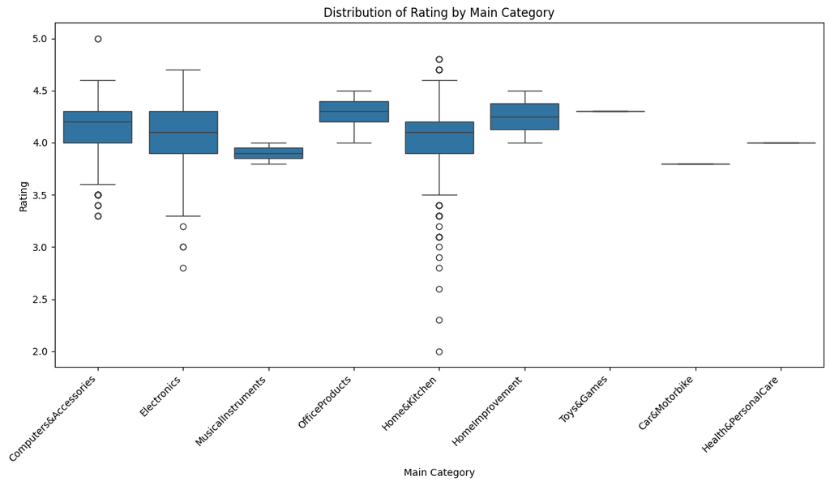

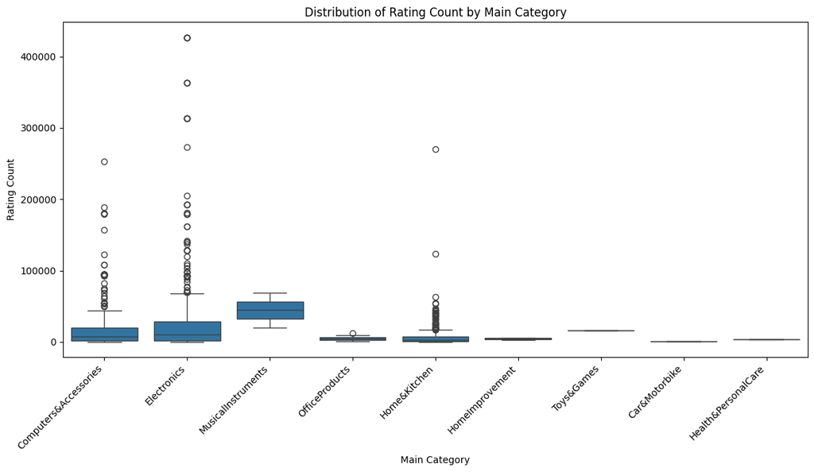

```python
# Create a box plot for rating by main_category
plt.figure(figsize=(12, 7))
sns.boxplot(x='main_category', y='rating', data=data_clean)
plt.title('Distribution of Rating by Main Category')
plt.xlabel('Main Category')
plt.ylabel('Rating')
plt.xticks(rotation=45, ha='right')
plt.tight_layout()
plt.show()

# Create a box plot for rating_count by main_category
plt.figure(figsize=(12, 7))
sns.boxplot(x='main_category', y='rating_count', data=data_clean)
plt.title('Distribution of Rating Count by Main Category')
plt.xlabel('Main Category')
plt.ylabel('Rating Count')
plt.xticks(rotation=45, ha='right')
plt.tight_layout()
plt.show()
```

## Visualize the distribution of `rating` and `rating_count`

Use histograms to understand the distributions of the `rating` and `rating_count` columns.

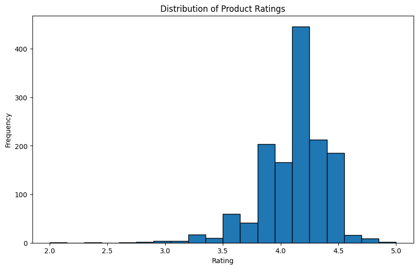

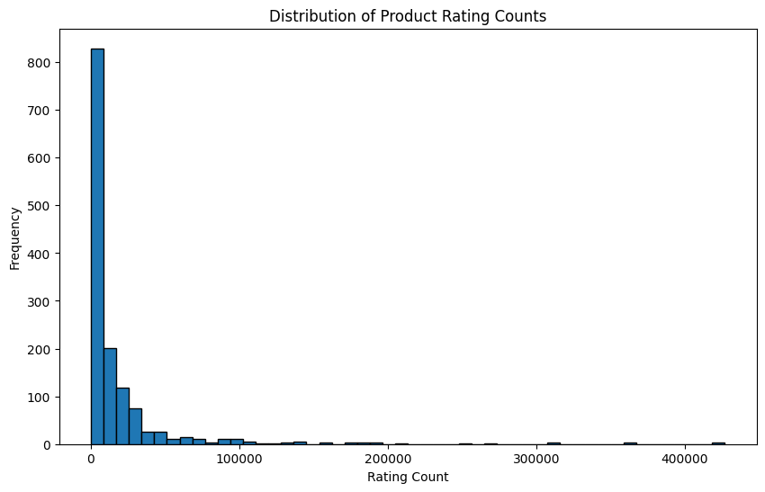

```python
# Create a histogram of rating
plt.figure(figsize=(10, 6))
plt.hist(data_clean['rating'].dropna(), bins=20, edgecolor='black')
plt.xlabel('Rating')
plt.ylabel('Frequency')
plt.title('Distribution of Product Ratings')
plt.show()

# Create a histogram of rating_count
plt.figure(figsize=(10, 6))
plt.hist(data_clean['rating_count'], bins=50, edgecolor='black')
plt.xlabel('Rating Count')
plt.ylabel('Frequency')
plt.title('Distribution of Product Rating Counts')
plt.show()
```

## Visualize the distribution of `discount_percentage`

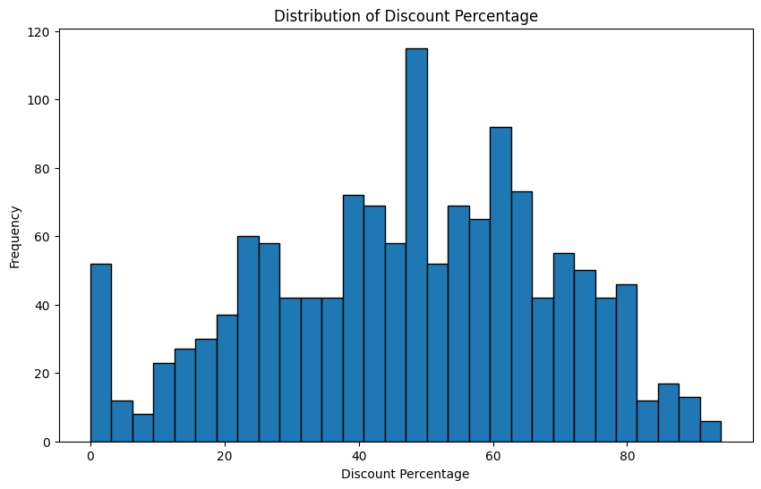

```python
# Create a histogram of discount_percentage
plt.figure(figsize=(10, 6))
plt.hist(data_clean['discount_percentage'], bins=30, edgecolor='black')
plt.xlabel('Discount Percentage')
plt.ylabel('Frequency')
plt.title('Distribution of Discount Percentage')
plt.show()
```

## Visualize relationships between features

Use a correlation matrix and heatmap to see the relationships between the dataset's features.

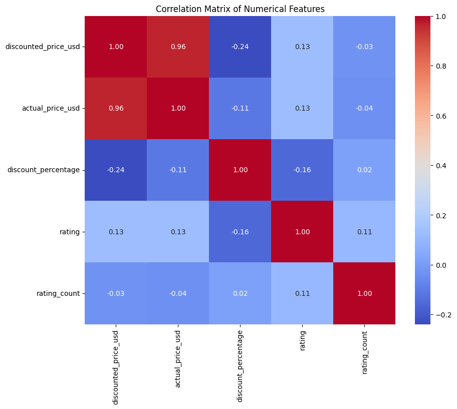

```python
# Select numerical features
numerical_cols = ['discounted_price_usd', 'actual_price_usd', 'discount_percentage', 'rating', 'rating_count']
data_numerical = data_clean[numerical_cols]

# Calculate the correlation matrix
correlation_matrix = data_numerical.corr()

# Create a heatmap
plt.figure(figsize=(10, 8))
sns.heatmap(correlation_matrix, annot=True, cmap='coolwarm', fmt=".2f")
plt.title('Correlation Matrix of Numerical Features')
plt.show()
```

# Part 3 - Model Selection

## One-hot encode the `main_category` feature.

```python
# One-hot encode main_category
data_clean = pd.get_dummies(data_clean, columns=['main_category'], drop_first=True)

# Rename the one-hot encoded columns to remove the prefix
data_clean.columns = data_clean.columns.str.replace('main_category_', '', regex=False)

# Results
display(data_clean.head())
```

|  | product_id | product_name | category | discounted_price | actual_price | discount_percentage | rating | rating_count | discounted_price_usd | actual_price_usd | Computers&Accessories | Electronics | Health&PersonalCare | Home&Kitchen | HomeImprovement | MusicalInstruments | OfficeProducts | Toys&Games |
| --- | --- | --- | --- | --- | --- | --- | --- | --- | --- | --- | --- | --- | --- | --- | --- | --- | --- | --- |
| 0 | B07JW9H4J1 | Wayona Nylon Braided USB to Lightning Fast Cha... | Computers&Accessories\|Accessories&Peripherals\|... | 399.0 | 1099.0 | 64.0 | 4.2 | 24269.0 | 4.788 | 13.188 | True | False | False | False | False | False | False | False |
| 1 | B098NS6PVG | Ambrane Unbreakable 60W / 3A Fast Charging 1.5... | Computers&Accessories\|Accessories&Peripherals\|... | 199.0 | 349.0 | 43.0 | 4.0 | 43994.0 | 2.388 | 4.188 | True | False | False | False | False | False | False | False |
| 2 | B096MSW6CT | Sounce Fast Phone Charging Cable & Data Sync U... | Computers&Accessories\|Accessories&Peripherals\|... | 199.0 | 1899.0 | 90.0 | 3.9 | 7928.0 | 2.388 | 22.788 | True | False | False | False | False | False | False | False |
| 3 | B08HDJ86NZ | boAt Deuce USB 300 2 in 1 Type-C & Micro USB S... | Computers&Accessories\|Accessories&Peripherals\|... | 329.0 | 699.0 | 53.0 | 4.2 | 94363.0 | 3.948 | 8.388 | True | False | False | False | False | False | False | False |
| 4 | B08CF3B7N1 | Portronics Konnect L 1.2M Fast Charging 3A 8 P... | Computers&Accessories\|Accessories&Peripherals\|... | 154.0 | 399.0 | 61.0 | 4.2 | 16905.0 | 1.848 | 4.788 | True | False | False | False | False | False | False | False |

## Apply Log Transformation To `rating_count`

Our target variable is highly skewed, so we'll apply a log transformation so that it works better with out predictive model.

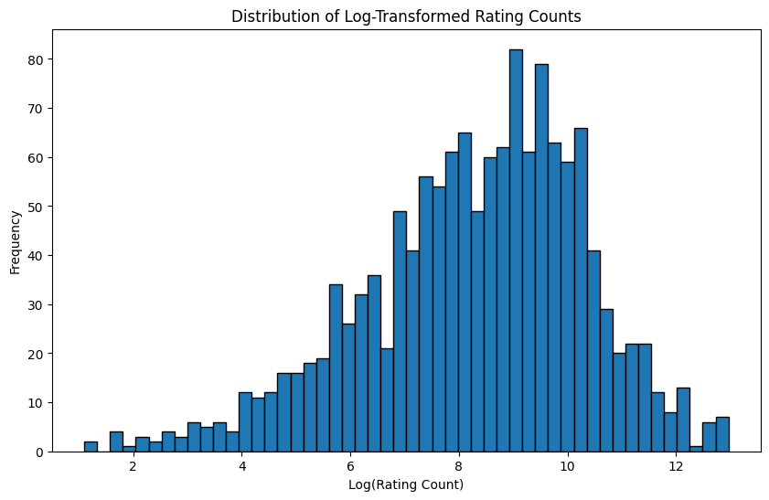

```
Sample of data with transformed rating count:
```

|  | product_id | product_name | category | discounted_price | actual_price | discount_percentage | rating | rating_count | discounted_price_usd | actual_price_usd | Computers&Accessories | Electronics | Health&PersonalCare | Home&Kitchen | HomeImprovement | MusicalInstruments | OfficeProducts | Toys&Games | rating_count_log |
| --- | --- | --- | --- | --- | --- | --- | --- | --- | --- | --- | --- | --- | --- | --- | --- | --- | --- | --- | --- |
| 0 | B07JW9H4J1 | Wayona Nylon Braided USB to Lightning Fast Cha... | Computers&Accessories\|Accessories&Peripherals\|... | 399.0 | 1099.0 | 64.0 | 4.2 | 24269.0 | 4.788 | 13.188 | True | False | False | False | False | False | False | False | 10.096996 |
| 1 | B098NS6PVG | Ambrane Unbreakable 60W / 3A Fast Charging 1.5... | Computers&Accessories\|Accessories&Peripherals\|... | 199.0 | 349.0 | 43.0 | 4.0 | 43994.0 | 2.388 | 4.188 | True | False | False | False | False | False | False | False | 10.691831 |
| 2 | B096MSW6CT | Sounce Fast Phone Charging Cable & Data Sync U... | Computers&Accessories\|Accessories&Peripherals\|... | 199.0 | 1899.0 | 90.0 | 3.9 | 7928.0 | 2.388 | 22.788 | True | False | False | False | False | False | False | False | 8.978282 |
| 3 | B08HDJ86NZ | boAt Deuce USB 300 2 in 1 Type-C & Micro USB S... | Computers&Accessories\|Accessories&Peripherals\|... | 329.0 | 699.0 | 53.0 | 4.2 | 94363.0 | 3.948 | 8.388 | True | False | False | False | False | False | False | False | 11.454915 |
| 4 | B08CF3B7N1 | Portronics Konnect L 1.2M Fast Charging 3A 8 P... | Computers&Accessories\|Accessories&Peripherals\|... | 154.0 | 399.0 | 61.0 | 4.2 | 16905.0 | 1.848 | 4.788 | True | False | False | False | False | False | False | False | 9.735424 |

```python
# Apply log transformation to rating_count
data_clean['rating_count_log'] = np.log1p(data_clean['rating_count'])

# Display the distribution of the transformed target variable
plt.figure(figsize=(10, 6))
plt.hist(data_clean['rating_count_log'], bins=50, edgecolor='black')
plt.xlabel('Log(Rating Count)')
plt.ylabel('Frequency')
plt.title('Distribution of Log-Transformed Rating Counts')
plt.show()

print("Sample of data with transformed rating count:")
display(data_clean.head())
```

## Separate Features And Target

```python
# Separate features and the new log-transformed target
X_all_transformed = data_clean.drop(['rating_count', 'rating_count_log'], axis=1) # Drop original and new log target for features
y_transformed = data_clean['rating_count_log']

print(f"Features shape (after transformation): {X_all_transformed.shape}")
print(f"Transformed Target shape: {y_transformed.shape}")
```

```
Features shape (after transformation): (1381, 17)
Transformed Target shape: (1381,)
```

## Use The Nested Holdout Method To Split Data

```python
# Split the data with the transformed target
X_temp_transformed, X_test_transformed, y_temp_transformed, y_test_transformed = train_test_split(X_all_transformed, y_transformed, test_size=0.2, random_state=42)
X_train_transformed, X_val_transformed, y_train_transformed, y_val_transformed = train_test_split(X_temp_transformed, y_temp_transformed, test_size=0.25, random_state=42)

print("\nData split sizes (after transformation):")
print(f"Training:   {len(X_train_transformed)} samples ({len(X_train_transformed)/len(X_all_transformed)*100:.1f}%)")
print(f"Validation: {len(X_val_transformed)} samples ({len(X_val_transformed)/len(X_all_transformed)*100:.1f}%)")
print(f"Test:       {len(X_test_transformed)} samples ({len(X_test_transformed)/len(X_all_transformed)*100:.1f}%)")
print(f"Total:      {len(X_all_transformed)} samples")
```

```
Data split sizes (after transformation):
Training:   828 samples (60.0%)
Validation: 276 samples (20.0%)
Test:       277 samples (20.1%)
Total:      1381 samples
```

## Define The Feature Sets

```python
# Define the feature sets (using columns that exist in X_all_transformed)
feature_sets_transformed = {
    'Minimal': ['discounted_price_usd', 'actual_price_usd'],
    'Basic': ['discounted_price_usd', 'actual_price_usd', 'Computers&Accessories', 'Electronics', 'Health&PersonalCare', 'Home&Kitchen', 'HomeImprovement', 'MusicalInstruments', 'OfficeProducts', 'Toys&Games'],
    'All Original': [col for col in X_all_transformed.columns if col not in ['product_id', 'product_name', 'category']],
}
```

## Train And Evaluate Our Models

```python
# Initialize a DataFrame to store results
results_df_transformed = pd.DataFrame(columns=['Feature Set', 'Num Features', 'Train RMSE', 'Val RMSE', 'Train R²', 'Val R²', 'Generalization Gap'])

# Train and evaluate Linear Regression model
for name, features in feature_sets_transformed.items():
    # Select the features for the current set
    X_train_fs_transformed = X_train_transformed[features]
    X_val_fs_transformed = X_val_transformed[features]

    # Initialize and train the Linear Regression model
    model_transformed = LinearRegression()

    # Scale the features
    scaler = StandardScaler()
    X_train_fs_scaled = scaler.fit_transform(X_train_fs_transformed)
    X_val_fs_scaled = scaler.transform(X_val_fs_transformed)

    model_transformed.fit(X_train_fs_scaled, y_train_transformed)

    # Predict on training and validation sets
    y_train_pred_transformed = model_transformed.predict(X_train_fs_scaled)
    y_val_pred_transformed = model_transformed.predict(X_val_fs_scaled)

    # Calculate RMSE and R² for training and validation sets
    train_rmse_transformed = np.sqrt(mean_squared_error(y_train_transformed, y_train_pred_transformed))
    val_rmse_transformed = np.sqrt(mean_squared_error(y_val_transformed, y_val_pred_transformed))
    train_r2_transformed = r2_score(y_train_transformed, y_train_pred_transformed)
    val_r2_transformed = r2_score(y_val_transformed, y_val_pred_transformed)

    # Calculate generalization gap
    generalization_gap_transformed = train_rmse_transformed - val_rmse_transformed

    # Store the results
    results_df_transformed = pd.concat([results_df_transformed, pd.DataFrame({
        'Feature Set': [name],
        'Num Features': [len(features)],
        'Train RMSE': [train_rmse_transformed],
        'Val RMSE': [val_rmse_transformed],
        'Train R²': [train_r2_transformed],
        'Val R²': [val_r2_transformed],
        'Generalization Gap': [generalization_gap_transformed]
    })], ignore_index=True)

# Display the results
display(results_df_transformed)
```

|  | Feature Set | Num Features | Train RMSE | Val RMSE | Train R² | Val R² | Generalization Gap |
| --- | --- | --- | --- | --- | --- | --- | --- |
| 0 | Minimal | 2 | 1.972732 | 2.085949 | 0.009103 | -0.003545 | -0.113217 |
| 1 | Basic | 10 | 1.882011 | 2.032515 | 0.098144 | 0.047211 | -0.150503 |
| 2 | All Original | 14 | 1.810002 | 1.942568 | 0.165837 | 0.129674 | -0.132566 |

## Visualize the Generalization Gap For Each Feature Set

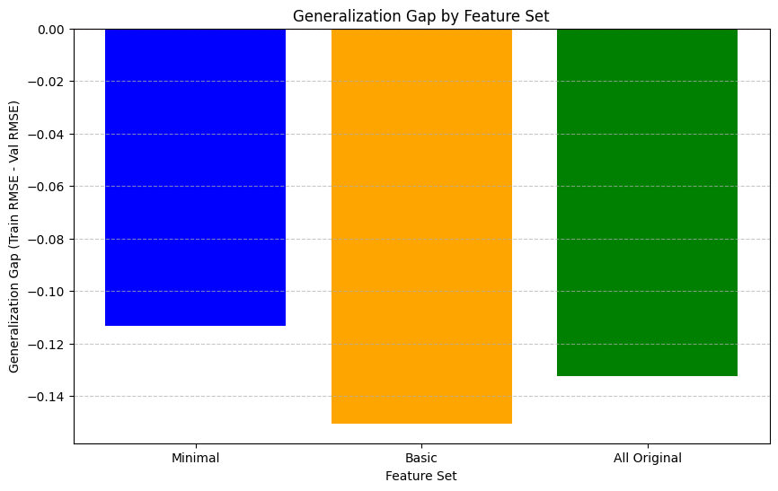

```python
# Visualize the Generalization Gap
plt.figure(figsize=(10, 6))
plt.bar(results_df_transformed['Feature Set'], results_df_transformed['Generalization Gap'], color=['blue', 'orange', 'green'])
plt.xlabel('Feature Set')
plt.ylabel('Generalization Gap (Train RMSE - Val RMSE)')
plt.title('Generalization Gap by Feature Set')
plt.axhline(0, color='red', linestyle='--', linewidth=0.8)
plt.grid(axis='y', linestyle='--', alpha=0.7)
plt.show()
```

## Visualize The Validation RMSE For Each Feature Set

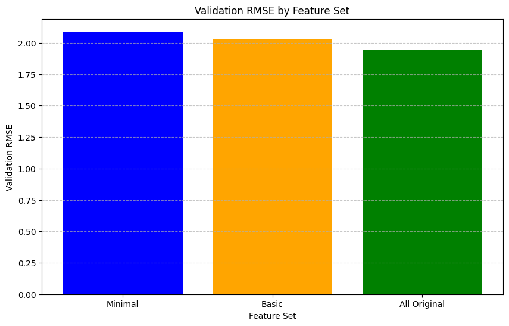

```python
# Visualize Validation RSME
plt.figure(figsize=(10, 6))
plt.bar(results_df_transformed['Feature Set'], results_df_transformed['Val RMSE'], color=['blue', 'orange', 'green'])
plt.xlabel('Feature Set')
plt.ylabel('Validation RMSE')
plt.title('Validation RMSE by Feature Set')
plt.grid(axis='y', linestyle='--', alpha=0.7)
plt.show()
```

## Model Selection Decision

```python
# Select best model based on validation RMSE
best_idx = results_df_transformed['Val RMSE'].idxmin()
best_model = results_df_transformed.loc[best_idx, 'Feature Set']

print(f"Selected Model: {best_model}")
print(f"Validation RMSE: {results_df_transformed.loc[best_idx, 'Val RMSE']:.4f}")
print(f"Generalization Gap: {results_df_transformed.loc[best_idx, 'Generalization Gap']:.4f}")
```

```
Selected Model: All Original
Validation RMSE: 1.9426
Generalization Gap: -0.1326
```

## FINAL Performance Estimation On Test Set

```python
# Get the selected feature set
selected_features = feature_sets_transformed[best_model]

# Combine train and validation data for final training
X_train_final = pd.concat([X_train_transformed[selected_features], X_val_transformed[selected_features]], ignore_index=True)
y_train_final = pd.concat([y_train_transformed, y_val_transformed], ignore_index=True)

# Get test set
X_test_final = X_test_transformed[selected_features]
y_test_final = y_test_transformed

# Train final model on combined train+val set
from sklearn.pipeline import Pipeline

final_pipeline = Pipeline([
    ('scaler', StandardScaler()),
    ('model', LinearRegression())
])

final_pipeline.fit(X_train_final, y_train_final)

# Evaluate on train set
y_train_pred = final_pipeline.predict(X_train_final)
train_rmse = np.sqrt(mean_squared_error(y_train_final, y_train_pred))
train_r2 = r2_score(y_train_final, y_train_pred)

# Evaluate on test set
y_test_pred = final_pipeline.predict(X_test_final)
test_rmse = np.sqrt(mean_squared_error(y_test_final, y_test_pred))
test_r2 = r2_score(y_test_final, y_test_pred)

print(f"\nFinal Performance Estimation (Test Set):")
print(f"Model: {best_model}")
print(f"Train RMSE: {train_rmse:.4f}")
print(f"Train R²: {train_r2:.4f}")
print(f"Test RMSE: {test_rmse:.4f}")
print(f"Test R²: {test_r2:.4f}")
print(f"Generalization Gap: {test_rmse - train_rmse:.4f}")
```

```
Final Performance Estimation (Test Set):
Model: All Original
Train RMSE: 1.8413
Train R²: 0.1609
Test RMSE: 1.9895
Test R²: 0.1629
Generalization Gap: 0.1482
```

# Part 4 - Predictive Modeling

Now that we have selected and trained our model, we can use it to predict rating_count for new data.

```python
# Create a sample of new data with the same columns as X_test_final
sample_new_data = pd.DataFrame({
    'discounted_price': [500.0],
    'actual_price': [1000.0],
    'discount_percentage': [50.0],
    'rating': [4.5],
    'discounted_price_usd': [6.0],
    'actual_price_usd': [12.0],
    'Computers&Accessories': [False],
    'Electronics': [False],
    'Health&PersonalCare': [False],
    'Home&Kitchen': [True],
    'HomeImprovement': [False],
    'MusicalInstruments': [False],
    'OfficeProducts': [False],
    'Toys&Games': [False]
})

# Make predictions on the new data
predicted_rating_count_log = final_pipeline.predict(sample_new_data[selected_features])

# Inverse transform the predictions to get the original scale
predicted_rating_count = np.expm1(predicted_rating_count_log)

print(f"Predicted rating count: {predicted_rating_count[0]:.4f}")
```

```
Predicted rating count: 2889.1601
```

```python
# Second sample of new data
sample_new_data_2 = pd.DataFrame({
    'discounted_price': [250.0],
    'actual_price': [500.0],
    'discount_percentage': [50.0],
    'rating': [3.8],
    'discounted_price_usd': [3.0],
    'actual_price_usd': [6.0],
    'Computers&Accessories': [True],
    'Electronics': [False],
    'Health&PersonalCare': [False],
    'Home&Kitchen': [False],
    'HomeImprovement': [False],
    'MusicalInstruments': [False],
    'OfficeProducts': [False],
    'Toys&Games': [False]
})

# Make predictions on the new data
predicted_rating_count_log_2 = final_pipeline.predict(sample_new_data_2[selected_features])

# Inverse transform the predictions to get the original scale
predicted_rating_count_2 = np.expm1(predicted_rating_count_log_2)

print(f"Predicted rating count: {predicted_rating_count_2[0]:.4f}")
```

```
Predicted rating count: 3493.3572
```

Assuming rating_count only consists of those who have actually bought the product, we can now estimate how many sales a product will recieve based on its features.

# Part 5 - Conclusion

For the predictive modeling for `rating_count` (assuming everyone who reviewed the product bought it), the LinearRegression model with the 'All Original' feature set performed the best on the validation set, achieving the lowest RMSE out of all the feature sets. The final evaluation on the test set showed a similar performance.

While the model gives an estimate for `rating_count`, the R² value suggests that the selected features only explain a portion of the variance in `rating_count`. This means that other factors not included in this dataset likely influence the number of ratings a product receives. For the scope of this project, however, I feel that the features selected and analyzed are approprate.

```python
# Install nbconvert if needed
!pip install nbconvert
# Convert this notebook to HTML
! jupyter nbconvert --to html "/content/drive/MyDrive/Colab Notebooks/amazon_sales_project_final.ipynb" --output project
```

```
[NbConvertApp] Converting notebook /content/drive/MyDrive/Colab Notebooks/amazon_sales_project_final.ipynb to html
[NbConvertApp] WARNING | Alternative text is missing on 10 image(s).
[NbConvertApp] Writing 1243529 bytes to /content/drive/MyDrive/Colab Notebooks/project.html
```